```python
from IPython.display import HTML, display

HTML('''<script>
code_show=true;
function code_toggle() {
 if (code_show){
 $('div.input').hide();
 } else {
 $('div.input').show();
 }
 code_show = !code_show
}
$( document ).ready(code_toggle);
</script>
<form action="javascript:code_toggle()"><input type="submit" value="Click here to toggle on/off the raw code."></form>''')
```

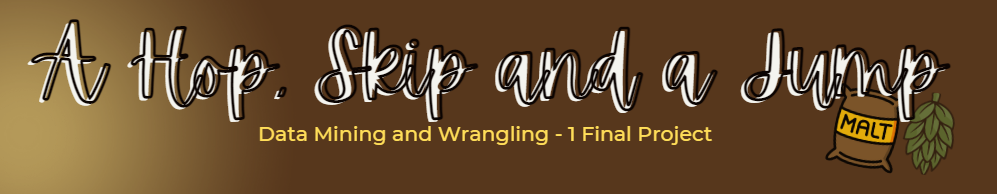

```python
Image('dmw1-cover-photo.PNG')
```

# Identifying Relationships in Beer Using Latent Factor Analysis

## Executive Summary

Beer has become a deep beverage with a very diverse set of flavors. However, when talking about beers, most people use categories based on yeasts, which fail to capture the nuances and flavor profiles of many beers. Given this, our group wanted to see if we can use data science to better describe the unique relationships of a beers ingredients and its properties.

Our data was scraped from Punk API v2, a REST API that connects to a database of beer records with their measurable attributes as well as their ingredients. The ingredients property was represented in the form of a heavily nested JSON file, so it had to be normalized into 3 sparse dataframes. Using this data, dimensionality reduction was performed. First, Principal Component Analysis was done on a dataset containing only the measurable attributes and a dataset containing those attributes with the yeast. Singular Value Decomposition was performed on three datasets: malts, hops, and a full dataset containing both the measurable attributes and ingredients.

Finally, we want to recommend the following: (1) consider including the method of preparation as a data type, (2) record at what point the hops were added instead of just the total amount of hops added, and (3) categorize hops according to flavor profile to handle the diversity of hop types.

## Introduction

In recent years, beer has become an artisanal hobby like wine and whiskey. Gone are the days where we think beers are just simple bar drinks that all taste the same. Today, people are very conscious of the ingredients used and the quality of the flavor. When they talk about beers, they normally classify them based on the yeast that was used, like Ale, Lager, etc.

Giving more depth about the ingredients of a beer, malts are sugars and grains that contribute to the sugary flavor of a beer. For example, if you ever had a beer that tastes like bread or chocolate, that would be considered a malty beer. On the other hand, hops contribute to the aroma and bitterness of a beer. If you ever had a beer that tastes fruity, those would be considered hoppy beers.

There is a large spectrum of flavors lost due to a lack of meaningful categories. We feel that the current classifications of beers are simply not enough. Given this, our group wanted to determine if we can represent that spectrum better.

## Problem Statement

How can we use Dimensionality Reduction and Latent Factor Analysis to analyze the relationships between beer ingredients and their properties?

## Methodology

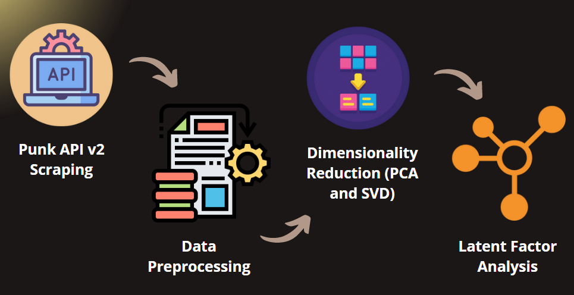

```python
from IPython.display import Image, display
Image('metho.PNG')
```

### Scraping

The data was scraped from Punk API v2. This is a database containing records of beers with their properties and ingredients. The endpoint used to get beers was `https://api.punkapi.com/v2/beers`. 80 beers were collected per API call, and there were 5 total API calls. The total dataset contains 325 beers. The data was stored in a SQLite Database for ease of access.

```python
import requests
import pandas as pd
import numpy as np
import sqlite3
import json
```

```python
# Same functions as always

def create_conn():
    """
    Function creates a sqlite database
    and returns a sqlite connection to
    be used. If db already exists, simply
    returns connection.

    Returns
    -------
    conn
        SQLite connection to project database.
    """

    conn = sqlite3.connect('final_project.db')
    return conn

def create_beers_table(conn):
    """
    Function will create a SQLite Database with
    a beers table.

    Parameters
    ----------
    conn
        SQLite Connection to project database.
    """

    conn.execute("DROP TABLE IF EXISTS beers")
    sql = """
    CREATE TABLE beers(
        id INT,
        name VARCHAR(30) NOT NULL,
        abv FLOAT,
        ibu FLOAT,
        target_fg FLOAT,
        target_og FLOAT,
        ebc FLOAT,
        srm FLOAT,
        ph FLOAT,
        attenuation_level FLOAT,
        volume TEXT,
        boil_volume TEXT,
        method TEXT,
        ingredients TEXT,
        food_pairing TEXT
    )
    """

    conn.execute(sql)

def get_beers(conn):
    counter = 1
    dropcols = ['tagline',
                'first_brewed',
                'description',
                'image_url',
                'brewers_tips',
                'contributed_by']
    str_cols = ['volume',
                'boil_volume',
                'method',
                'ingredients',
                'food_pairing']
    while True:
        url = f'https://api.punkapi.com/v2/beers?page={counter}&per_page=80'
        beers = requests.get(url).json()
        if len(beers) == 0:
            break
        df = pd.DataFrame(beers).drop(columns=dropcols)
        for col in str_cols:
            df[col] = df[col].astype(str).replace('\'', '\"')
        df.to_sql('beers', conn, if_exists='append', index=False)
        counter += 1

def make_df():
    """
    Function will connect to a SQLite database
    containing beers and then return a dataframe containing
    the contents of that table.

    Returns
    -------
    df : pd.DataFrame
        Dataframe containing beers data.
    """

    conn = create_conn()
    sql = "SELECT * FROM beers"
    df = pd.read_sql(sql, conn)
    str_cols = ['volume',
                'boil_volume',
                'method',
                'ingredients',
                'food_pairing']
    for col in str_cols:
            df[col] = df[col].str.replace('\'', '\"')
    conn.close()
    return df
```

The following snippet are the function calls used to create a database from scratch and load beers as dataframe.

```
     create_beers_table(conn)
     get_beers(conn)
     conn.close()
     df = make_df()
```

```python
# conn = create_conn()
# try:
#     create_beers_table(conn)
#     get_beers(conn)
#     conn.close()
#     df = make_df()
# except Exception as e:
#     print(e)
#     conn.close()
```

```python
df = make_df()
```

### Data Preprocessing

```python
display(df)
```

|  | id | name | abv | ibu | target_fg | target_og | ebc | srm | ph | attenuation_level | volume | boil_volume | method | ingredients | food_pairing |
| --- | --- | --- | --- | --- | --- | --- | --- | --- | --- | --- | --- | --- | --- | --- | --- |
| 0 | 1 | Buzz | 4.5 | 60.0 | 1010.0 | 1044.0 | 20.0 | 10.0 | 4.4 | 75.0 | {"value": 20, "unit": "litres"} | {"value": 25, "unit": "litres"} | {"mash_temp": [{"temp": {"value": 64, "unit": ... | {"malt": [{"name": "Maris Otter Extra Pale", "... | ["Spicy chicken tikka masala", "Grilled chicke... |
| 1 | 2 | Trashy Blonde | 4.1 | 41.5 | 1010.0 | 1041.7 | 15.0 | 15.0 | 4.4 | 76.0 | {"value": 20, "unit": "litres"} | {"value": 25, "unit": "litres"} | {"mash_temp": [{"temp": {"value": 69, "unit": ... | {"malt": [{"name": "Maris Otter Extra Pale", "... | ["Fresh crab with lemon", "Garlic butter dippi... |
| 2 | 3 | Berliner Weisse With Yuzu - B-Sides | 4.2 | 8.0 | 1007.0 | 1040.0 | 8.0 | 4.0 | 3.2 | 83.0 | {"value": 20, "unit": "litres"} | {"value": 25, "unit": "litres"} | {"mash_temp": [{"temp": {"value": 60, "unit": ... | {"malt": [{"name": "Propino Pale Malt", "amoun... | ["Smoked chicken wings", "Miso ramen", "Yuzu c... |
| 3 | 4 | Pilsen Lager | 6.3 | 55.0 | 1012.0 | 1060.0 | 30.0 | 15.0 | 4.4 | 80.0 | {"value": 20, "unit": "litres"} | {"value": 25, "unit": "litres"} | {"mash_temp": [{"temp": {"value": 65, "unit": ... | {"malt": [{"name": "Extra Pale", "amount": {"v... | ["Spicy crab cakes", "Spicy cucumber and carro... |
| 4 | 5 | Avery Brown Dredge | 7.2 | 59.0 | 1027.0 | 1069.0 | 10.0 | 5.0 | 4.4 | 67.0 | {"value": 20, "unit": "litres"} | {"value": 25, "unit": "litres"} | {"mash_temp": [{"temp": {"value": 66, "unit": ... | {"malt": [{"name": "Lager Malt", "amount": {"v... | ["Vietnamese squid salad", "Chargrilled corn o... |
| ... | ... | ... | ... | ... | ... | ... | ... | ... | ... | ... | ... | ... | ... | ... | ... |
| 320 | 321 | Jinx Pale Ale | 4.7 | 35.0 | 1008.0 | 1043.0 | 13.0 | 7.0 | 4.6 | 81.0 | {"value": 20, "unit": "litres"} | {"value": 25, "unit": "litres"} | {"mash_temp": [{"temp": {"value": 63, "unit": ... | {"malt": [{"name": "Pale Ale", "amount": {"val... | ["Monterey Jack stuffed grilled jalapeños", "... |
| 321 | 322 | Jet Trash | 6.9 | 65.0 | 1008.0 | 1060.0 | 18.0 | 9.0 | 4.6 | 87.0 | {"value": 20, "unit": "litres"} | {"value": 25, "unit": "litres"} | {"mash_temp": [{"temp": {"value": 65, "unit": ... | {"malt": [{"name": "Pale Ale", "amount": {"val... | ["Roast chicken", "Seared steak", "Crusty bread"] |
| 322 | 323 | Interstate Vienna Lager. | 5.0 | 25.0 | 1007.0 | 1045.0 | 14.0 | 7.0 | 4.2 | 84.0 | {"value": 20, "unit": "litres"} | {"value": 25, "unit": "litres"} | {"mash_temp": [{"temp": {"value": 67, "unit": ... | {"malt": [{"name": "Pilsner", "amount": {"valu... | ["Grilled chicken and steamed vegetables", "Po... |
| 323 | 324 | Fools Gold Dortmunder Lager | 5.6 | 32.0 | 1009.0 | 1052.0 | 11.0 | 6.0 | 4.2 | 83.0 | {"value": 20, "unit": "litres"} | {"value": 25, "unit": "litres"} | {"mash_temp": [{"temp": {"value": 65, "unit": ... | {"malt": [{"name": "Pilsner", "amount": {"valu... | ["Seafood salad", "Sweet and sour pork", "Lemo... |
| 324 | 325 | Zipcode | 5.0 | 37.0 | 1006.0 | 1044.0 | 5.0 | 3.0 | 4.4 | 86.0 | {"value": 20, "unit": "litres"} | {"value": 25, "unit": "litres"} | {"mash_temp": [{"temp": {"value": 50, "unit": ... | {"malt": [{"name": "Pilsner", "amount": {"valu... | ["Goat"s cheese salad", "Pesto pasta", "Lemon ... |

325 rows × 15 columns

*Table 1. Dataframe of scraped beers from Punk API*

For the purposes of the study, the following preprocessing steps were performed. Firstly, any beers with null values were simply dropped. Secondly, the columns for food pairing, volume, boil volume, and method were dropped because the study simply wanted to focus on properties and ingredients.

### Data Description

#### Numerical Columns

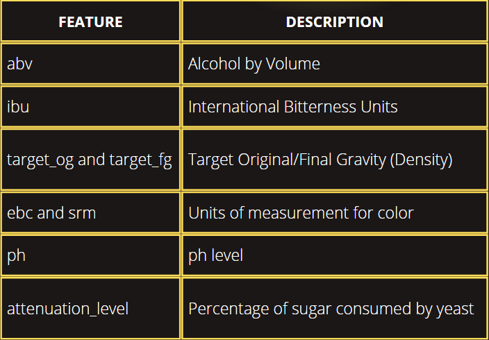

```python
Image('num_feats_beer.PNG')
```

*Table 2. Description of Numerical Features*

The table above contains descriptions for the numerical features of the dataset. These columns are measurable attributes of a beer such as alcohol percentage, international bitterness units, and attenuation level.

#### Ingredients JSON

```python
print(json.loads(df.iloc[0].ingredients))
```

```
{'malt': [{'name': 'Maris Otter Extra Pale', 'amount': {'value': 3.3, 'unit': 'kilograms'}}, {'name': 'Caramalt', 'amount': {'value': 0.2, 'unit': 'kilograms'}}, {'name': 'Munich', 'amount': {'value': 0.4, 'unit': 'kilograms'}}], 'hops': [{'name': 'Fuggles', 'amount': {'value': 25, 'unit': 'grams'},…
```

*Figure 1. Sample Ingredient JSON*

The figure above is a sample ingredients feature. The data is a heavily nested JSON object containing the malts, hops, and yeasts used to brew the beer. In order to preprocess this data, the JSON was normalized into sparse dataframes for each ingredient.

One observation is that some ingredients have units for grams while others had kilograms. For standardization, values for hops and malts were converted to grams. This was not necessary for yeast, because the data did not contain yeast amount.

The hops JSON contains a property called "add", which determines when the hop was added in the brewing process. According to The Brew Hut, hops added at the start contribute to bitterness while hops added at the end contribute to flavor. For the purposes of this study, that process was disregarded and we made the assumption to only take the total sum of hops without considering when they were added.

```python
def create_ingredients(df):
    """
    Function will create sparse dataframes for each
    ingredient type in the beers dataset.
    """

    malts = pd.DataFrame()
    hops = pd.DataFrame()
    for i, row in df.iterrows():
        try:
            ing_json = json.loads(row['ingredients'])
            malt = pd.json_normalize(ing_json,
                                     'malt')

            malt['name'] = "(MALT) " + malt['name']
            malt['id'] = row['id']
            malt['amount.value'] = np.where(malt['amount.unit'] == 'kilograms',
                                    malt['amount.value'] * 1000,
                                    malt['amount.value'])
            p_malt = malt.pivot(index='id',
                                columns='name',
                                values='amount.value')
            malts = pd.concat([malts, p_malt])
        except:
            pass

        try:
            ing_json = json.loads(row['ingredients'])
            hop = pd.json_normalize(ing_json, 'hops')
            hop['amount.value'] = np.where(hop['amount.unit'] == 'kilograms',
                                           hop['amount.value'] * 1000,
                                           hop['amount.value'])
            hop_sum = hop.groupby('name')['amount.value'].sum().reset_index()
            hop_sum['id'] = row['id']
            hop_sum['name'] = '(HOPS) '+ hop_sum['name']
            p_hops = hop_sum.pivot(index='id',
                                   columns='name',
                                   values='amount.value')
            hops = pd.concat([hops, p_hops])
        except:
            pass

    yeasts = pd.DataFrame()
    for i, row in df.iterrows():
        try:
            ing_json = json.loads(row['ingredients'])
            yeast = pd.json_normalize(ing_json)
            yeast['id'] = row['id']
            yeasts = pd.concat([yeasts, yeast[['id', 'yeast']]])
        except:
            pass
    return malts, hops, yeasts
```

```python
malts, hops, yeasts = create_ingredients(df)
```

The code snippet below is used to create the sparse dataframes:

`malts, hops, yeasts = create_ingredients(df)`

The table below shows the final sparse dataframe for each ingredient.

```python
display(malts.iloc[:, :10].head())
display(hops.iloc[:, :10].head())
display(pd.get_dummies(yeasts).iloc[:, :10].head())
```

| name id | (MALT) Caramalt | (MALT) Maris Otter Extra Pale | (MALT) Munich | (MALT) Acidulated Malt for kettle souring | (MALT) Propino Pale Malt | (MALT) Propino Pale Malt for kettle souring | (MALT) Wheat Malt | (MALT) Dark Crystal | (MALT) Extra Pale | (MALT) Lager Malt |
| --- | --- | --- | --- | --- | --- | --- | --- | --- | --- | --- |
| 1 | 200.0 | 3300.0 | 400.0 | NaN | NaN | NaN | NaN | NaN | NaN | NaN |
| 2 | 200.0 | 3250.0 | 400.0 | NaN | NaN | NaN | NaN | NaN | NaN | NaN |
| 3 | NaN | NaN | NaN | 30.0 | 1630.0 | 30.0 | 1630.0 | NaN | NaN | NaN |
| 4 | 250.0 | NaN | 250.0 | NaN | NaN | NaN | NaN | 60.0 | 4580.0 | NaN |
| 5 | NaN | NaN | NaN | NaN | NaN | NaN | NaN | NaN | NaN | 6630.0 |

| name id | (HOPS) Cascade | (HOPS) First Gold | (HOPS) Fuggles | (HOPS) Amarillo | (HOPS) Motueka | (HOPS) Simcoe | (HOPS) Bramling Cross | (HOPS) Centennial | (HOPS) Saaz | (HOPS) Nelson Sauvin |
| --- | --- | --- | --- | --- | --- | --- | --- | --- | --- | --- |
| 1 | 37.5 | 62.5 | 62.5 | NaN | NaN | NaN | NaN | NaN | NaN | NaN |
| 2 | NaN | NaN | NaN | 40.1 | 18.8 | 13.8 | NaN | NaN | NaN | NaN |
| 3 | NaN | NaN | NaN | NaN | NaN | NaN | 10.0 | NaN | NaN | NaN |
| 4 | NaN | NaN | NaN | 32.5 | NaN | NaN | NaN | 32.5 | NaN | NaN |
| 5 | NaN | NaN | NaN | NaN | NaN | NaN | NaN | NaN | 180.0 | NaN |

|  | id | yeast_Champagne | yeast_Safale US-05 | yeast_Saflager S189 | yeast_Saflager W-34/70 | yeast_WLP013 - London Ale | yeast_WLP099 - Super High Gravity Ale | yeast_WLP351 - Bavarian Weizen | yeast_WLP4000 - Vermont Ale | yeast_WLP500 - Monastery Ale |
| --- | --- | --- | --- | --- | --- | --- | --- | --- | --- | --- |
| 0 | 1 | 0 | 0 | 0 | 0 | 0 | 0 | 0 | 0 | 0 |
| 0 | 2 | 0 | 0 | 0 | 0 | 0 | 0 | 0 | 0 | 0 |
| 0 | 3 | 0 | 0 | 0 | 0 | 0 | 0 | 0 | 0 | 0 |
| 0 | 4 | 0 | 0 | 0 | 0 | 0 | 0 | 0 | 0 | 0 |
| 0 | 5 | 0 | 0 | 0 | 0 | 0 | 0 | 0 | 0 | 0 |

*Table 3-5. Sparse Dataframes for Ingredients (First 10 columns)*

### Dimensionality Reduction

Principal Component Analysis (PCA) was performed on the dataframe of only numerical attributes and numerical attributes with the yeast property. Principal Component Analysis is a method of dimensionality reduction that involves taking the eigenvectors of the covariance matrix to determine the features that contribute highly to explained variance.

\begin{align} \mathbf{Vw'} &= \lambda\mathbf{w'}. \end{align}

The process of PCA involves finding lines, planes and hyper-planes in the K-dimensional space that approximate the data as well as possible in the least squares sense. A line or plane that is the least squares approximation of a set of data points makes the variance of the coordinates on the line or plane as large as possible.

Singular Value Decomposition (SVD) was then performed three different datasets: the Malts dataset, Hops dataset, and a full dataset containing both measurable attribtues and both ingredients. Yeast was not included because in our problem statement, the focus of the study is to find relationships and categories that do not involve traditional classifications of yeast.

SVD was used for these datasets instead of PCA because most beers have about 3 or 4 malts and 2 or 3 hops. Given this, the data is expected to be incredibly sparse. In this case, SVD would be better to use. It involves decomposing a matrix and truncating the output in order to get a smaller matrix with the features that capture the most explained variance. To analyze the contribution of the features to each singular vector, Latent Factor Analysis was used.

\begin{align} \mathbf{D}=\mathbf{Q\Sigma P}^T \end{align}

The singular values in the diagonal matrix Σ can be used to understand the amount of variance explained by each of the singular vectors. We can use the first k columns of V and Σ and achieve U’ with fewer columns without losing much of the explained variance.

## Results and Discussion

For all dimensionality reduction implementations, the threshold for cumulative explained variance was 80% to determine the optimal number of Principal Components or Singular Vectors. All datasets were also scaled using minmax scaler.

## PCA

### PCA on Numerical Columns

The first dimensionality reduction method we performed was PCA on a dataset containing only the measurable attributes of a beer. This was to determine whether or not we can identify relationships between them.

```python
from sklearn.decomposition import PCA, TruncatedSVD, NMF
from sklearn.preprocessing import MinMaxScaler, StandardScaler
import matplotlib.pyplot as plt
```

[output not shown]

```python
CSS = """
.output {
    align-items: center;
}
"""

HTML('<style>{}</style>'.format(CSS))
```

```python
basic_cols = ['abv',
              'ibu',
              'target_fg',
              'target_og',
              'ebc',
              'srm',
              'ph',
              'attenuation_level']
df_num = df[basic_cols]
```

```python
pca = PCA()
scaler = MinMaxScaler()
X_scale = scaler.fit_transform(df_num.dropna())
X_new = pca.fit_transform(X_scale)
```

```python
cum_var = pca.explained_variance_ratio_.cumsum()
```

```
Number of PCs to retain: 3
```

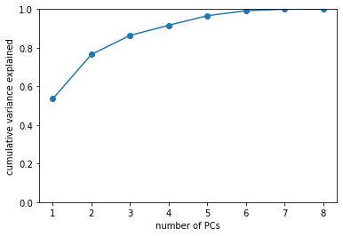

```python
plt.plot(range(1, len(cum_var)+1),
         cum_var, 'o-')
plt.ylim(0,1)
plt.xlabel('number of PCs')
plt.ylabel('cumulative variance explained');
n = np.where(cum_var == cum_var[cum_var > 0.8][0])[0][0] + 1
print("Number of PCs to retain:", n)
```

*Figure 2. Cumulative Variance Explained for PCA on Numerical Columns*

```python
pca = PCA(3)
X_new = pca.fit_transform(X_scale)
w = pca.components_
```

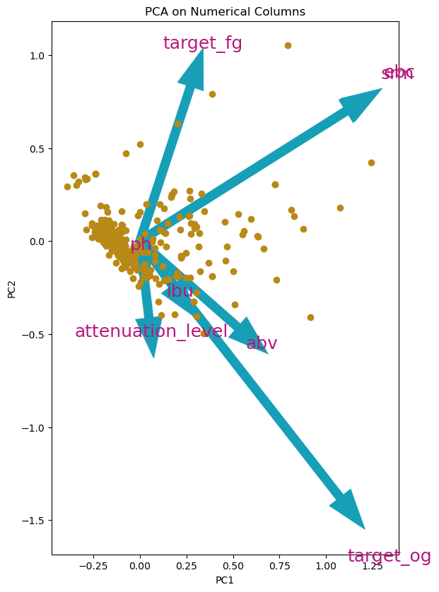

```python
# from lecture
fig, ax = plt.subplots(1, 1, subplot_kw=dict(aspect='equal'), dpi=100, figsize=(15, 10))
features = df_num.columns
# features = np.concatenate((bhp.feature_names[:3], bhp.feature_names[4:]))
for feature, vec in zip(features, w.T):
    ax.arrow(0, 0, 2*vec[0], 2*vec[1], width=0.05, ec='none', color='#179fb8')
    ax.text(2.5*vec[0], 2.5*vec[1], feature, ha='center', color='#B8177E', fontsize=18)
ax.scatter(X_new[:,0], X_new[:,1], color="#b88917")
ax.set_title('PCA on Numerical Columns')
ax.set_xlabel('PC1')
ax.set_ylabel('PC2');
```

*Figure 3. Plot of Data Projected on First 2 PCs with Feature Vectors*

Based on the plot above, the beers projected in the first 2 PCs do not show any meaningful clusters or trends. However, looking at the feature vectors we can see that attenuation_level is anticorrelated with final gravity and ebc/srm which are color attributes. This tells us that beers with a higher attenuation have a lighter color and lower density.

### PCA on Numerical Columns with Yeast

The yeast column was added to the numerical columns to determine if PCA could yield better relationships and clusters. This was done to see if traditional classifications of beer by their yeasts have meaningful relationships with the numerical attributes of a beer.

```python
df_yeast = pd.merge(df, yeasts, on='id', how='left')
df_yeast_clean = pd.get_dummies(df_yeast[basic_cols + ['yeast']])
scaler = MinMaxScaler()
X_scale = scaler.fit_transform(df_yeast_clean.dropna())
pca = PCA()
X_new = pca.fit_transform(X_scale)
```

```
Number of PCs to retain: 7
```

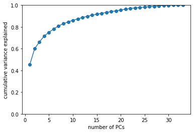

```python
cum_var = pca.explained_variance_ratio_.cumsum()
plt.plot(range(1, len(cum_var)+1),
         cum_var, 'o-')
plt.ylim(0,1)
plt.xlabel('number of PCs')
plt.ylabel('cumulative variance explained');
n = np.where(cum_var == cum_var[cum_var > 0.8][0])[0][0] + 1
print("Number of PCs to retain:", n)
```

*Figure 4. Cumulative Variance Explained for PCA on Numerical Columns with Yeast*

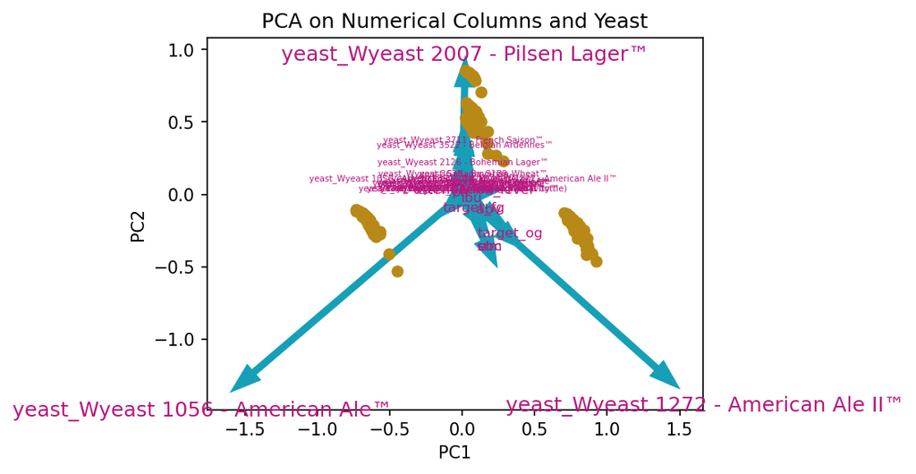

```python
n = 7
pca = PCA(n)
X_new = pca.fit_transform(X_scale)
w = pca.components_
# from lecture
fig, ax = plt.subplots(1, 1, subplot_kw=dict(aspect='equal'), dpi=150)
feat_d = ['yeast_Wyeast 1056 - American Ale™',
          'yeast_Wyeast 2007 - Pilsen Lager™',
          'yeast_Wyeast 1272 - American Ale II™'
         ]
features = df_yeast_clean.columns
for feature, vec in zip(features, w.T):
    ax.arrow(0, 0, 2*vec[0], 2*vec[1], width=0.05, ec='none', color='#179fb8')
    if feature in feat_d:
        fontsize = 12
    elif feature in basic_cols:
        fontsize = 8
    else:
        fontsize = 5
    ax.text(2.5*vec[0], 2.5*vec[1],
            feature,
            ha='center',
            color='#B8177E',
            fontsize=fontsize)
ax.scatter(X_new[:,0], X_new[:,1], color="#b88917")
ax.set_title('PCA on Numerical Columns and Yeast')
ax.set_xlabel('PC1')
ax.set_ylabel('PC2');
```

*Figure 5. Plot of Data Projected on First 2 PCs with Yeast Feature Vectors*

Based on the results, 3 clusters were formed on the plot. However, these clusters are heavily defined by the type of yeast used, with American Ale, American Ale II, and Pilsen Lager contributing the most to each cluster. While PCA managed to create distinct clusters, it was not able to answer the problem statement, which was to represent the spectrum of flavors among beers better.

So at the end, this only confirms what we already know, that beers can generally be classified by the type of yeast they use. However, malts and hops affect the bitterness and flavor of a beer greatly. Is it possible to do latent factor analysis to generate more insights on beer?

## SVD and Factor Analysis

SVD was performed on individual ingredients datasets first in order to get insights on the flavor profiles of ingredients. This was done by plotting the latent factors, looking at groups of correlated features, and determining what kind of flavors these ingredient groups have.

For visualization, only the top 10 singular vectors were plotted. Each plot is a horizontal bar chart that shows the top 10 features that influence the singular vector in descending absolute value.

When doing latent factor analysis, the websites Crisp Malt and Hops List were used as reference to determine the flavor profile of the ingredient.

### SVD on Malts

```python
scaler = MinMaxScaler()
malts_clean = pd.DataFrame(scaler.fit_transform(malts.fillna(0)),
                           columns=malts.columns)
```

```python
malts_svd = TruncatedSVD(malts_clean.shape[1])
malts_new = malts_svd.fit_transform(malts_clean.fillna(0))
cum_var = np.sort(malts_svd.explained_variance_ratio_)[::-1].cumsum()
n = np.where(cum_var == cum_var[cum_var > 0.8][0])[0][0] + 1
```

```
88 features reduced to 33
```

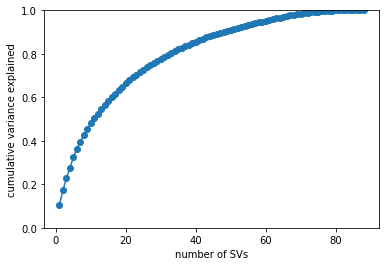

```python
# cum_var = pca.explained_variance_ratio_.cumsum()
plt.plot(range(1, len(cum_var)+1),
         cum_var, 'o-')
plt.ylim(0,1)
plt.xlabel('number of SVs')
plt.ylabel('cumulative variance explained');
# n = np.where(cum_var == cum_var[cum_var > 0.8][0])[0][0] + 1
print(f"{malts.shape[1]} features reduced to {n}")
```

*Figure 6. Cumulative Variance Explained for SVD on Malts Dataset*

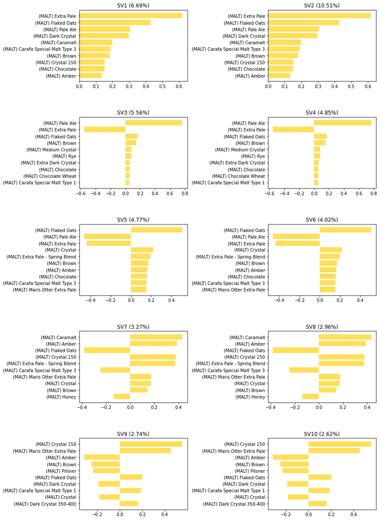

```python
malts_svd = TruncatedSVD(n)
malts_new = malts_svd.fit_transform(malts_clean.fillna(0))
p = malts_svd.components_.T
var_set = malts_svd.explained_variance_ratio_
feature_names = malts_clean.columns
# plt.rcParams['figure.figsize'] = (20, 20)
fig, ax = plt.subplots(nrows=5, ncols=2, figsize=(20, 20))
plt.subplots_adjust(wspace=0.75, right=0.6, hspace=0.5, top=0.9, bottom=0.1)
# fig.tight_layout()
svcount = 0
for i in range(5):
    for j in range(2):
#     fig, ax = plt.subplots()
        order = np.argsort(np.abs(p[:, i]))[-10:]
        ax[i][j].barh([feature_names[o] for o in order], p[order, i], color='#ffde59')
        ax[i][j].set_title(f'SV{svcount+1} ({var_set[svcount]*100:.2f}%)')
        svcount += 1
```

*Figure 7. Plot of Top 10 Latent Factors for Malts*

### SVD on Hops

In order to improve the results of SVD, hops columns were dropped if only one beer contained them. This is to limit variety ingredients like blueberry juice that are not necessarily considered traditional hops.

```python
stats = hops.describe().T
test_cols = stats[(stats['count'] > 1)].index
hops_clean = hops[test_cols].fillna(0)
# hops_clean = hops
scaler = MinMaxScaler()
hops_clean = pd.DataFrame(scaler.fit_transform(hops_clean), columns=hops_clean.columns)
```

```python
hops_svd = TruncatedSVD(hops_clean.shape[1])
hops_new = hops_svd.fit_transform(hops_clean.fillna(0))
cum_var = np.sort(hops_svd.explained_variance_ratio_)[::-1].cumsum()
```

```
65 features reduced to 31
```

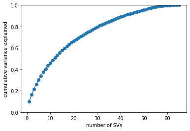

```python
# cum_var = pca.explained_variance_ratio_.cumsum()
plt.plot(range(1, len(cum_var)+1),
         cum_var, 'o-')
plt.ylim(0,1)
plt.xlabel('number of SVs')
plt.ylabel('cumulative variance explained');
n = np.where(cum_var == cum_var[cum_var > 0.8][0])[0][0] + 1
print(f"{hops_clean.shape[1]} features reduced to {n}")
```

*Figure 8. Cumulative Variance Explained for SVD on Hops Dataset*

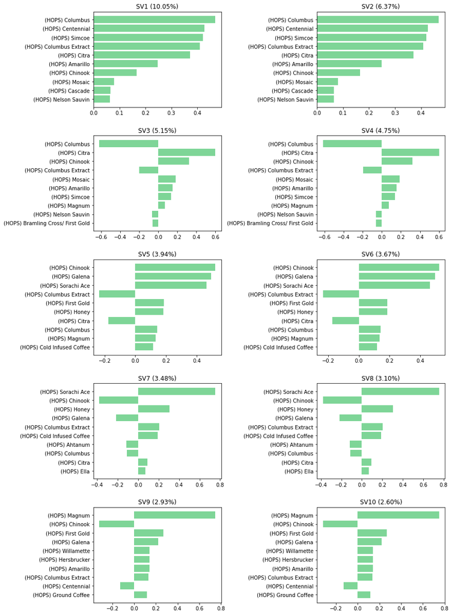

```python
hops_svd = TruncatedSVD(n)
hops_new = hops_svd.fit_transform(hops_clean.fillna(0))
p = hops_svd.components_.T
var_set = hops_svd.explained_variance_ratio_
feature_names = hops_clean.columns
# plt.rcParams['figure.figsize'] = (20, 20)
fig, ax = plt.subplots(nrows=5, ncols=2, figsize=(20, 20))
plt.subplots_adjust(wspace=0.75, right=0.6, hspace=0.3, top=0.9, bottom=0.1)
svcount = 0
for i in range(5):
    for j in range(2):
        order = np.argsort(np.abs(p[:, i]))[-10:]
        ax[i][j].barh([feature_names[o] for o in order], p[order, i], color='#7ed597')
        ax[i][j].set_title(f'SV{svcount+1} ({var_set[svcount]*100:.2f}%)')
        svcount += 1
```

*Figure 9. Plot of Top 10 Latent Factors for Hops*

After performing SVD on the Hops dataset, 65 hops were reduced to 31 singular vectors. SVs 1 and 2 are postively defined by both bitter hops like Columbus as well as citrussy hops like Citra or Amarillo. This leads us to believe that those singular vectors represent the class of beers that are bitter and fruity. On the other hand, SVs 3 and 4 are positively defined by the citrussy hops but are negatively defined by Columbus hops. This implies that those vectors represent beers that are either only bitter or only fruity. What is important to note is that bitter hops and citrussy hops mostly contributed to the top 10 singular vectors. Other than Willamette and Hersbrucker, herby and spicy hops were not as represented.

### SVD on Complete Dataset

```python
# beers = malts.join(hops[test_cols].fillna(0), how='left')
beers = malts.join(hops_clean, how='left')
beers = beers.join(df.set_index('id')[basic_cols], how='left')
```

```python
scaler = MinMaxScaler()
beers = pd.DataFrame(scaler.fit_transform(beers.fillna(0)),
                           columns=beers.columns,
                           index=beers.index)
```

```python
svd = TruncatedSVD(beers.shape[1])
beers_new = svd.fit_transform(beers)
```

```python
cum_var = np.sort(svd.explained_variance_ratio_)[::-1].cumsum()
n = np.where(cum_var == cum_var[cum_var >= 0.8][0])[0][0] + 1
```

```
161 features reduced to 55
```

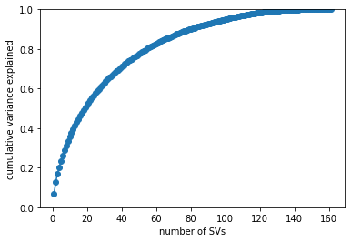

```python
# cum_var = pca.explained_variance_ratio_.cumsum()
plt.plot(range(1, len(cum_var)+1),
         cum_var, 'o-')
plt.ylim(0,1)
plt.xlabel('number of SVs')
plt.ylabel('cumulative variance explained');
n = np.where(cum_var == cum_var[cum_var > 0.8][0])[0][0] + 1
print(f"{beers.shape[1]} features reduced to {n}")
```

*Figure 10. Cumulative Variance Explained for SVD on Full Dataset*

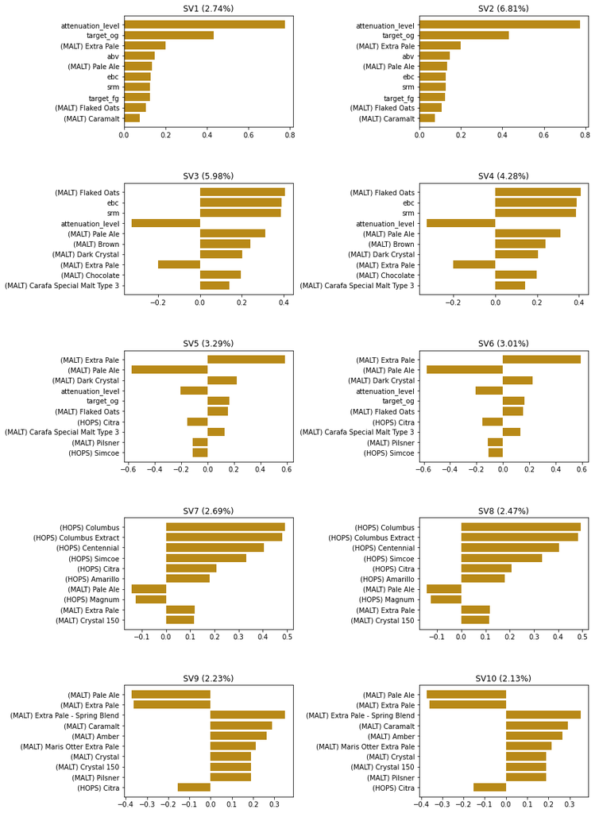

```python
svd = TruncatedSVD(n)
beers_new = svd.fit_transform(beers.fillna(0))
p = svd.components_.T
var_set = svd.explained_variance_ratio_
feature_names = beers.columns
# plt.rcParams['figure.figsize'] = (20, 20)
fig, ax = plt.subplots(nrows=5, ncols=2, figsize=(20, 20))
plt.subplots_adjust(wspace=0.75, right=0.6, hspace=0.5, top=0.9, bottom=0.1)
svcount = 0
for i in range(5):
    for j in range(2):
        order = np.argsort(np.abs(p[:, i]))[-10:]
        ax[i][j].barh([feature_names[o] for o in order], p[order, i], color='#b88917')
        ax[i][j].set_title(f'SV{svcount+1} ({var_set[svcount]*100:.2f}%)')
        svcount += 1
```

*Figure 11. Plot of Top 10 Latent Factors for Full Dataset*

After performing SVD on the full dataset, 161 features were reduced to 55. Majority of the SVs have either malts or numerical properties as top features, with the exception of SVs 7 and 8 which mainly contain hops. In the first two SVs, we can see that the top 2 features by far were attenuation level and original gravity. What is interesting about this is that abv is not a highly important feature for these two singular vectors. This makes sense considering most beers are in the 5% to 8% abv range unlike wines and whiskeys that have a wider range.

In SVs 3 and 4, the features that positively contribute are the nuttier malts like Flaked Oats, Dark Crystal, and Chocolate, and the numerical features ebc and srm, which are color intensity values. This implies that the nuttier beers tend to have darker colors, perhaps due to the nature of their ingredients. Another interesting observation is that they are anticorrelated with attenuation level, which is the percentage of sugar consumed. This means that nuttier beers tend to have a higher amount of sugar compared to less intense beers. This is probably where the "nutty" flavor comes from.

What is correlated with attenuation level however is Extra Pale. Extra Pale is a light-colored malt with a less intense flavor. Looking at SVs 7 and 8, we can find the citrussy and fruity hops correlated with Extra Pale and also Crystal 150, another type of light malt. This means that beers that use more citrussy hops tend to use lighter malts.

```python
df_svd = pd.DataFrame(beers_new,
                      columns=[f'SV{i+1}' for i in range(n)],
                      index=beers.index)
```

## Conclusions

### Insights

Based on the results of our SVD, we can see that nuttier malts contribute to a darker color and lower attenuation level. The model captured the pattern of dark beers with sweeter types of flavors. On the other hand, beers with a lot of citrussy hops like Simcoe and Citra pair with lighter malts like Extra Pale or Crystal 150. These beers would have a higher attenuation and lower sugar, which is interesting because we would not normally associate "fruitier" drinks with less sugar.

Overall, ingredients contributed a lot to the full dataset. Our model was able to capture the unique relationships of malts and hops on the flavor profile of the beer. However, the full dataset was only able to represent citrussy hops, and other hops that might be more floral, spicy, or herby like Willamette did not contribute as much to the singular vectors.

## Recommendations

### Final Reduced Dataset

```python
df_svd.iloc[:, :10]
```

| id | SV1 | SV2 | SV3 | SV4 | SV5 | SV6 | SV7 | SV8 | SV9 | SV10 |
| --- | --- | --- | --- | --- | --- | --- | --- | --- | --- | --- |
| 1 | 0.719235 | -0.171873 | -0.100466 | -0.067133 | 0.137999 | 0.061075 | 0.127447 | 0.021772 | -0.007413 | -0.016441 |
| 2 | 0.710178 | -0.174853 | -0.098118 | -0.100568 | 0.145467 | 0.051698 | 0.126023 | 0.043712 | 0.019746 | -0.005538 |
| 3 | 0.776907 | -0.292805 | -0.189736 | -0.045502 | 0.071049 | 0.338081 | -0.130969 | -0.323520 | -0.039970 | 0.343024 |
| 4 | 0.877251 | -0.252765 | 0.134458 | -0.064607 | -0.063191 | -0.054676 | -0.046424 | 0.066823 | -0.034201 | 0.000996 |
| 5 | 0.728398 | -0.134626 | -0.065388 | -0.078051 | 0.045111 | 0.020457 | 0.004879 | 0.024662 | 0.033190 | -0.008502 |
| ... | ... | ... | ... | ... | ... | ... | ... | ... | ... | ... |
| 321 | 0.787751 | -0.096237 | -0.300309 | -0.149965 | -0.046260 | -0.031348 | -0.034695 | 0.039608 | 0.024675 | -0.032419 |
| 322 | 0.922552 | -0.071229 | -0.395575 | -0.201469 | -0.100105 | -0.123178 | -0.033738 | 0.018635 | 0.018058 | 0.003122 |
| 323 | 0.798242 | -0.277792 | -0.189598 | -0.144080 | 0.184404 | 0.175333 | -0.138182 | 0.333611 | 0.019793 | 0.150779 |
| 324 | 0.815122 | -0.204804 | -0.240594 | -0.112276 | 0.114982 | 0.161728 | -0.147895 | 0.332583 | -0.016174 | 0.002694 |
| 325 | 0.802209 | -0.289054 | -0.224234 | -0.101430 | 0.180088 | 0.280255 | -0.195460 | 0.423459 | -0.039068 | 0.016154 |

324 rows × 10 columns

*Table 6. Final Reduced Dataset*

The table above contains the final reduced dataset of 55 features for the original 324 beers. This study can be extended by using this dataframe to recommend beers using a recommender system or information retrieval. Another possible extension is to use unsupervised learning methods to determine if the beers can be clustered more distinctly than dimensionality reduction.

### Data

The study was limited to only the ingredients and properties of a beer. Because of this, the method of brewing and temperature used to boil was disregarded. With domain knowledge, having clean data on how a beer was brewed could help generate more insightful observations.

A lot of assertions were also used in processing hops, such as dropping hops that only 1 beer used and using the total amount of hops instead of noting what stage of the process they were added. One recommendation is to parse the data to also label when the hop was added to see if being added at the start or end affects the results of dimensionality reduction. Another recommendation is to have a general index for the flavor profiles of hops. This is because hop types tend to be more diverse, being either fruits, herbs, or spices, unlike malts which are only varieties of grain or a sugar component like chocolate. Because of this, the flavor profiles of a hop were only subjectively determined in this study.

## References

[1] Punk API v2 REST API: https://punkapi.com/

[2] Adding Hops, The Brew Hut: https://thebrewhut.com/resources-recipes/brewing-basics/adding-hops/#:~:text=Hops%20are%20very%20versatile%20as,the%20boil%20will%20create%20aroma.

[3] Crisp Malt: https://crispmalt.com/

[4] Hops List: https://www.hopslist.com/

## Acknowledgements

- Prof Christian Alis - For expressing his passion in teaching (through lectures and comments) that inspired us to keep moving forward and finish DMW1
- Prof Pat Donato - For giving us suggestions on our study and telling us to look into the hops dataset a bit deeper
- Allan Geronimo - For giving his observations on our results and helping us realize how we can clarify our results better
- Guido van Rossum - For inventing Python and continuing to improve its features in version 3.11 so that we won't need to learn Julia yet